# GLM: regressione poissoniana e selezione del modello migliore

```r
# library(tidyverse)
library(dplyr)
library(readxl)
# library(HH)
library(sjPlot)
```

# Variabile dipendente e variabile esplicativa

Consideriamo sempre il dataset usato negli esempi precedenti, relativo allo studio di Panagakis et al. (2017). In questo studio, sono considerate 142 femmine di capra delle nevi, di cui 29 non si sono mai riprodotte.  
Ci concentriamo sulla longevità degli animali, che come abbiamo detto dipende da molti fattori che agiscono contemporaneamente - la densità nell’anno di nascita è soltanto uno di questi. Altre variabili che influenzano la longevità, come abbiamo visto, sono il fatto che le femmine si siano riprodotte oppure no (variabile esplicativa dicotomica).  
Per verificare se la longevità degli animali sia influenzata dalla *early reproductive allocation*, gli autori considerano quindi sia questa variabile, sia la densità alla nascita e la qualità degli animali. Queste variabili possono agire in modo additivo tra loro, o anche in interazione con la riproduzione.

Rileggiamo e prepariamo di nuovo i dati:

```r
mydata <- read_excel("data/CawRidge_LifetimeData.xlsx")
head(mydata)
```

| goat | YOB | agecaptured | longevity | AFR | ALR | ers34birth | ers34wean | ers3456birth | ers3456wean | ers123birth | ers123wean | LRSbirth | LRSwean | lateRSbirth | lateRSwean | meddensity | densityYOB | quality |
| --- | --- | --- | --- | --- | --- | --- | --- | --- | --- | --- | --- | --- | --- | --- | --- | --- | --- | --- |
| 1 | 1983 | 4 | 13 | NA | 10 | NA | NA | NA | NA | NA | NA | NA | NA | NA | NA | NA | NA | NA |
| 2 | 1984 | 4 | 15 | NA | 15 | NA | NA | NA | NA | NA | NA | NA | NA | NA | NA | 81 | NA | 2.8090000000000002 |
| 3 | 1983 | 5 | 11 | NA | 11 | NA | NA | NA | NA | NA | NA | NA | NA | NA | NA | NA | NA | NA |
| 4 | 1984 | 4 | 11 | NA | 8 | NA | NA | NA | NA | NA | NA | NA | NA | NA | NA | 81 | NA | NA |
| 5 | 1988 | 1 | 10 | 4 | 10 | 1 | 1 | 3 | 2 | 3 | 2 | 6 | 5 | 3 | 3 | 96 | NA | 0.39400000000000002 |
| 6 | 1989 | 1 | 10 | 4 | 10 | 1 | 1 | 3 | 3 | 3 | 3 | 6 | 6 | 3 | 3 | 104 | NA | 1.675 |

```r
mydata$densityYOB <- as.numeric(mydata$densityYOB)
```

```
Avvertimento: NA introdotti per coercizione
```

```r
mydata$quality <- as.numeric(mydata$quality)
```

```
Avvertimento: NA introdotti per coercizione
```

```r
mydata %>%
  dplyr::select(densityYOB, longevity, ALR, quality) %>%
  mutate(repr = "yes") %>%
  na.omit() -> mydata
mydata$repr[mydata$ALR == "never"] <- "no"
mydata$repr <- as.factor(mydata$repr)
```

Prima di decidere esattamenete che modello fittare, diamo un’occhiata alle relazioni che intercorrono tra la variabile dipendente e le variabili esplicative:

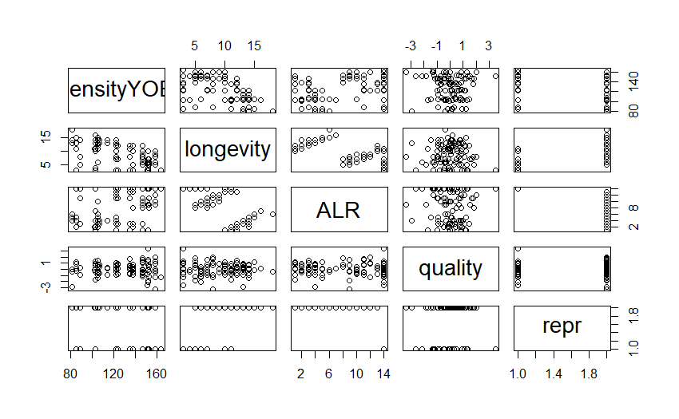

```r
plot(mydata)
```

Le relazioni tra la longevità e la densità e tra la longevità e la qualità degli animali non sono chiarissime, per cui potrebbero anche non essere lineari. Per questo le due variabili esplicative (densità alla nascita e qualità degli animali) saranno inserite nel modello come termini al quadrato.

Diamo inoltre un’occhiata alla variabile dipendente:

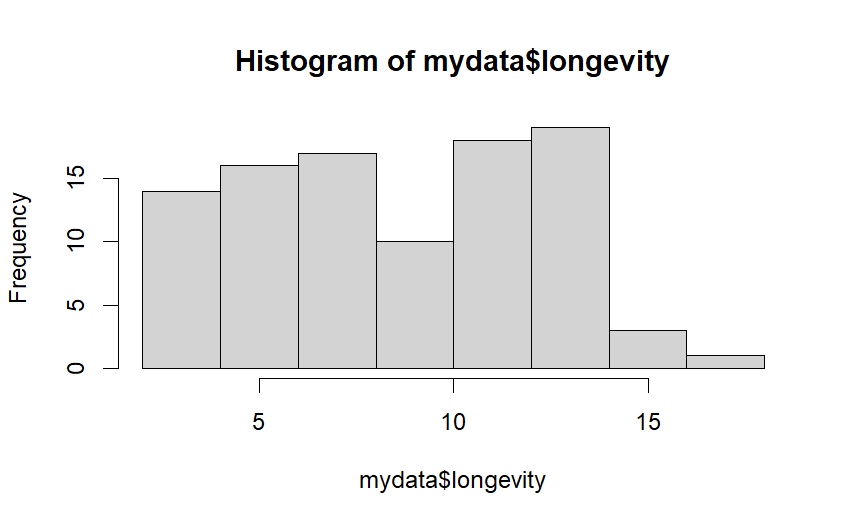

```r
hist(mydata$longevity)
```

Anche se fino ad ora abbiamo assunto che questi dati avessero una distribuzione normale, si tratta in realtà di un ‘conteggio’ del numero di anni, per cui è più appropriato modellizzare la sua relazione con le variabili dipendenti usando un modello di tipo poissoniano.

# Beyond optimal model

Fittiamo ora il modello di base ai dati - in questo caso faremo anche un esercizio di *model selection*, per cui partiremo dal modello più complesso possibile, il cosiddetto *beyond optimal model*:

```r
mod_v1 <- glm(longevity ~ poly(densityYOB, degree = 2)*repr + poly(quality, degree = 2)*repr,
              data = mydata,
             family = "poisson")
summary(mod_v1)
```

```
Call:
glm(formula = longevity ~ poly(densityYOB, degree = 2) * repr +
    poly(quality, degree = 2) * repr, family = "poisson", data = mydata)

Coefficients:
                                      Estimate Std. Error z value Pr(>|z|)
(Intercept)                            1.45382    0.11268  12.903  < 2e-16 ***
poly(densityYOB, degree = 2)1          1.64552    1.22487   1.343  0.17914
poly(densityYOB, degree = 2)2          0.46619    1.02697   0.454  0.64987
repryes                                0.83738    0.11898   7.038 1.95e-12 ***
poly(quality, degree = 2)1            -0.08833    0.94878  -0.093  0.92583
poly(quality, degree = 2)2            -1.17319    0.92469  -1.269  0.20453
poly(densityYOB, degree = 2)1:repryes -3.70530    1.28411  -2.885  0.00391 **
poly(densityYOB, degree = 2)2:repryes -0.98897    1.09453  -0.904  0.36623
repryes:poly(quality, degree = 2)1    -0.01039    1.03581  -0.010  0.99199
repryes:poly(quality, degree = 2)2     1.00792    1.04916   0.961  0.33671
---
Signif. codes:  0 ‘***’ 0.001 ‘**’ 0.01 ‘*’ 0.05 ‘.’ 0.1 ‘ ’ 1

(Dispersion parameter for poisson family taken to be 1)

    Null deviance: 170.315  on 97  degrees of freedom
Residual deviance:  57.197  on 88  degrees of freedom
AIC: 464.35

Number of Fisher Scoring iterations: 4
```

Visualizziamo graficamente il risultato del modello:

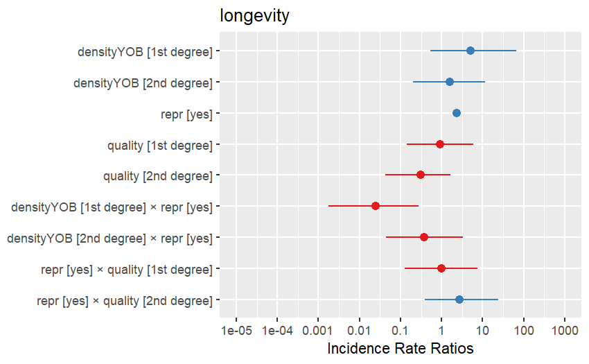

```r
plot_model(mod_v1)
```

Questo risultato ci dice che secondo il nostro primo modello, c’è un effetto della densità nell’anno di nascita sulla longevità, e che questo effetto cambia a seconda dell’attività riproduttiva.

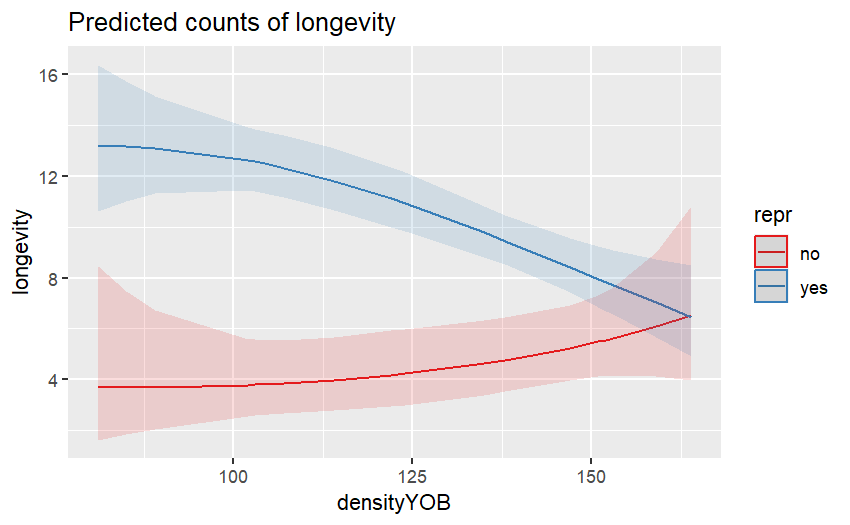

```r
plot_model(mod_v1, type = "eff", terms = c("densityYOB","repr"))
```

Se invece consideriamo la qualità degli animali, vediamo che non c’è un effetto di interazione:

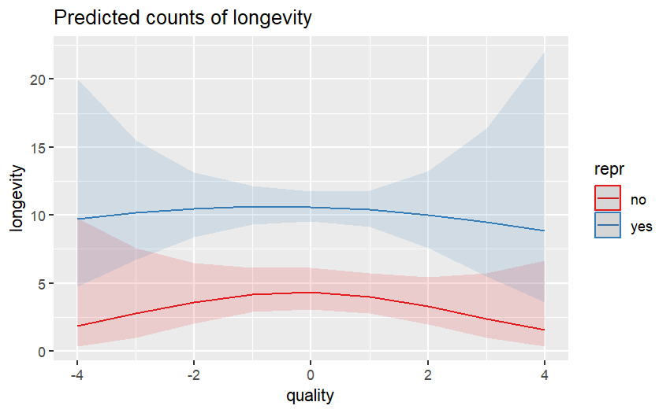

```r
plot_model(mod_v1, type = "eff", terms = c("quality","repr"))
```

In entrambi i casi però gli effetti di qualità e densità non sembrano lineari.  
In ogni caso, annotiamo il valore di AIC di questo modello:

```r
(AIC(mod_v1) -> AIC_mod1)
```

```
[1] 464.3475
```

# Model selection

Sembra che comunque possiamo semplificare un po’ il modello. Testiamo ora le strutture più semplici.

```r
mod_v2 <- glm(longevity ~ poly(densityYOB, degree = 2)*repr + poly(quality, degree = 2),
             data = mydata,
             family = "poisson")
summary(mod_v2)
```

```
Call:
glm(formula = longevity ~ poly(densityYOB, degree = 2) * repr +
    poly(quality, degree = 2), family = "poisson", data = mydata)

Coefficients:
                                      Estimate Std. Error z value Pr(>|z|)
(Intercept)                             1.4534     0.1127  12.901  < 2e-16 ***
poly(densityYOB, degree = 2)1           1.3784     1.1532   1.195    0.232
poly(densityYOB, degree = 2)2           0.4222     1.0294   0.410    0.682
repryes                                 0.8361     0.1190   7.025 2.14e-12 ***
poly(quality, degree = 2)1             -0.1754     0.3718  -0.472    0.637
poly(quality, degree = 2)2             -0.4334     0.4199  -1.032    0.302
poly(densityYOB, degree = 2)1:repryes  -3.3996     1.2111  -2.807    0.005 **
poly(densityYOB, degree = 2)2:repryes  -0.8909     1.0914  -0.816    0.414
---
Signif. codes:  0 ‘***’ 0.001 ‘**’ 0.01 ‘*’ 0.05 ‘.’ 0.1 ‘ ’ 1

(Dispersion parameter for poisson family taken to be 1)

    Null deviance: 170.315  on 97  degrees of freedom
Residual deviance:  58.211  on 90  degrees of freedom
AIC: 461.36

Number of Fisher Scoring iterations: 4
```

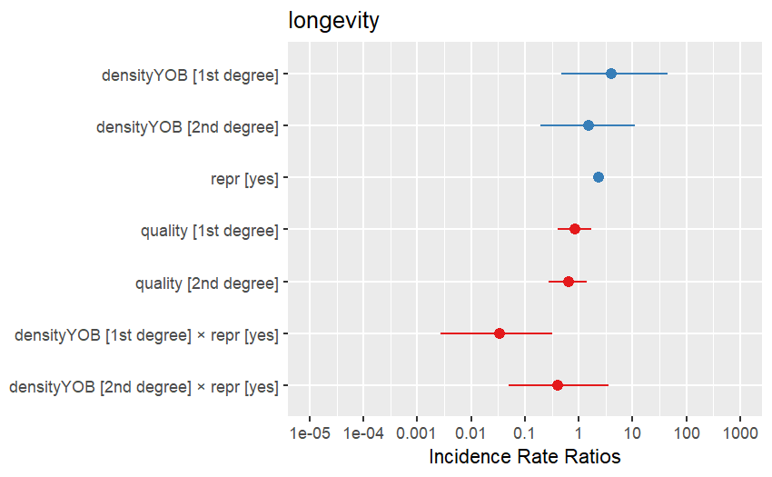

```r
plot_model(mod_v2)
```

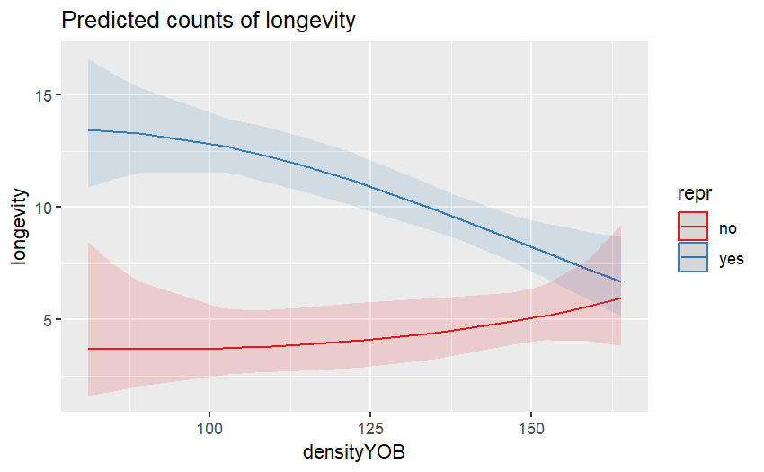

```r
plot_model(mod_v2, type = "eff", terms = c("densityYOB","repr"))
```

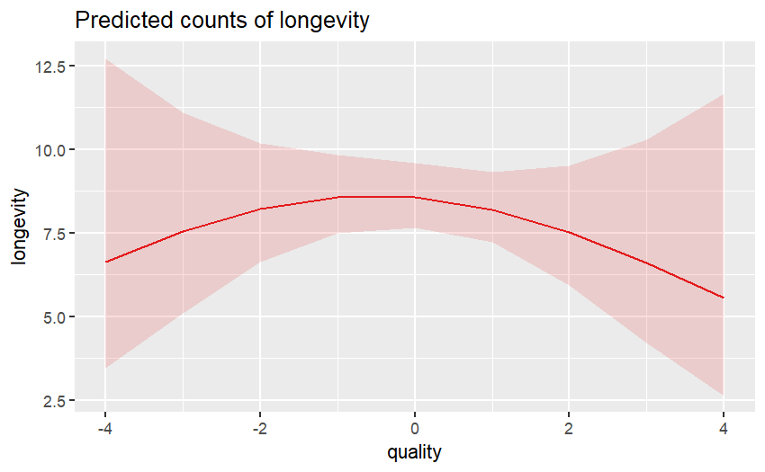

```r
plot_model(mod_v2, type = "eff", terms = c("quality"))
```

```r
(AIC(mod_v2) -> AIC_mod2)
```

```
[1] 461.3616
```

Pensate a tutte le strutture possibili di modelli e salvate i valori relativi di AIC:

```r
mod_v3 <- glm(longevity ~ poly(densityYOB, degree = 2) +
               poly(quality, degree = 2)*repr, data = mydata,
              family = "poisson")
summary(mod_v3)
```

```
Call:
glm(formula = longevity ~ poly(densityYOB, degree = 2) + poly(quality,
    degree = 2) * repr, family = "poisson", data = mydata)

Coefficients:
                                   Estimate Std. Error z value Pr(>|z|)
(Intercept)                          1.5593     0.1007  15.478  < 2e-16 ***
poly(densityYOB, degree = 2)1       -1.6326     0.3569  -4.574 4.78e-06 ***
poly(densityYOB, degree = 2)2       -0.2587     0.3503  -0.739    0.460
poly(quality, degree = 2)1          -1.2012     0.8843  -1.358    0.174
poly(quality, degree = 2)2          -0.1674     0.8535  -0.196    0.844
repryes                              0.7449     0.1081   6.890 5.58e-12 ***
poly(quality, degree = 2)1:repryes   1.0744     0.9792   1.097    0.273
poly(quality, degree = 2)2:repryes  -0.1485     0.9700  -0.153    0.878
---
Signif. codes:  0 ‘***’ 0.001 ‘**’ 0.01 ‘*’ 0.05 ‘.’ 0.1 ‘ ’ 1

(Dispersion parameter for poisson family taken to be 1)

    Null deviance: 170.31  on 97  degrees of freedom
Residual deviance:  68.02  on 90  degrees of freedom
AIC: 471.17

Number of Fisher Scoring iterations: 4
```

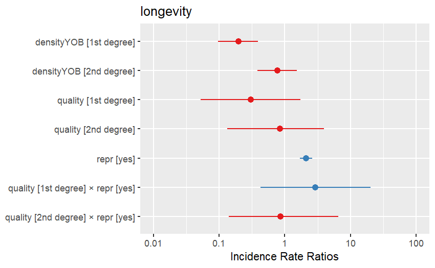

```r
plot_model(mod_v3)
```

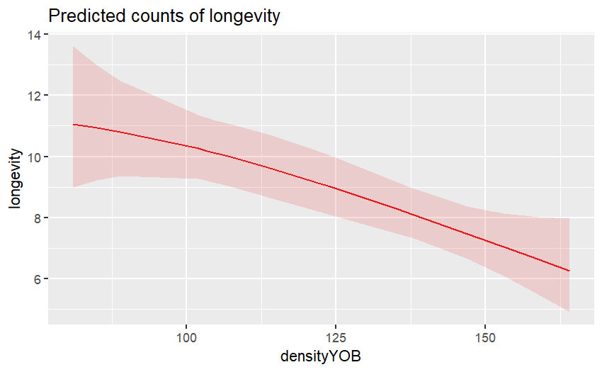

```r
plot_model(mod_v3, type = "eff", terms = c("densityYOB"))
```

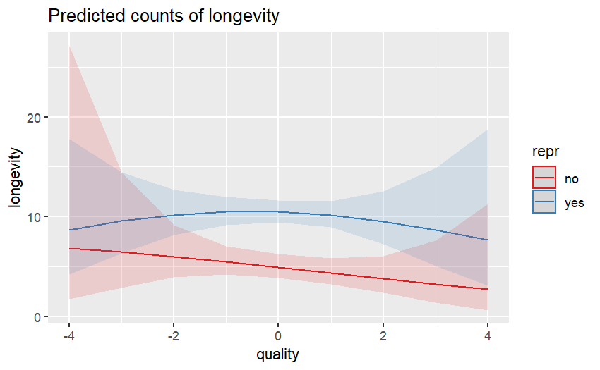

```r
plot_model(mod_v3, type = "eff", terms = c("quality","repr"))
```

```r
(AIC(mod_v3) -> AIC_mod3)
```

```
[1] 471.1705
```

```r
mod_v4 <- glm(longevity ~ densityYOB +
               quality + repr, data = mydata,
             family = "poisson")
summary(mod_v4)
```

```
Call:
glm(formula = longevity ~ densityYOB + quality + repr, family = "poisson",
    data = mydata)

Coefficients:
             Estimate Std. Error z value Pr(>|z|)
(Intercept)  2.408039   0.212754  11.318  < 2e-16 ***
densityYOB  -0.006609   0.001417  -4.664 3.10e-06 ***
quality     -0.020552   0.033027  -0.622    0.534
repryes      0.744429   0.105547   7.053 1.75e-12 ***
---
Signif. codes:  0 ‘***’ 0.001 ‘**’ 0.01 ‘*’ 0.05 ‘.’ 0.1 ‘ ’ 1

(Dispersion parameter for poisson family taken to be 1)

    Null deviance: 170.315  on 97  degrees of freedom
Residual deviance:  70.949  on 94  degrees of freedom
AIC: 466.1

Number of Fisher Scoring iterations: 4
```

```r
(AIC(mod_v4) -> AIC_mod4)
```

```
[1] 466.0998
```

## Tabella riassuntiva per la model selection

```r
n.modelli = 3
data.frame(struttura = c("mod1", "mod2", "mod3"),
           AICvalue = c(AIC_mod1, AIC_mod2, AIC_mod3)) %>%
  arrange(AICvalue) %>%
  mutate(deltaAIC = AICvalue - first(AICvalue))
```

| struttura | AICvalue | deltaAIC |
| --- | --- | --- |
| mod2 | 461.3616 | 0.000000 |
| mod1 | 464.3475 | 2.985939 |
| mod3 | 471.1705 | 9.808912 |

```r
n.modelli = 4
data.frame(struttura = c("mod1", "mod2", "mod3", "mod4"),
           AICvalue = c(AIC_mod1, AIC_mod2, AIC_mod3, AIC_mod4)) %>%
  arrange(AICvalue) %>%
  mutate(deltaAIC = AICvalue - first(AICvalue))
```

| struttura | AICvalue | deltaAIC |
| --- | --- | --- |
| mod2 | 461.3616 | 0.000000 |
| mod1 | 464.3475 | 2.985939 |
| mod4 | 466.0998 | 4.738230 |
| mod3 | 471.1705 | 9.808912 |